# Text Analysis - Discriminating words

Thorkil Klint

4/4/2018

# 1. Goals of this script

This script aims at conducting a discriminating words analysis across different party blocs in the Danish parliament. Following the bag of words assumption, I try to distinguish the use of words in statements made by 1) The government parties, 2) The right wing parti, Dansk Folkeparti, and 3) the left wing opposition.

This script contains both my text pre processing and the text analysis itself. As results in text analysis are heavily dependent on the pre processing, I have put them in the same script

## 2. Necessities

```r
rm(list=ls())
library(stringr) #For working with string data
library(tm) # Framework for text mining
```

```r
library(ggplot2) # for plotting word frequencies
library(dplyr)
library(RTextTools) # a machine learning package for text classification written in R
library(SnowballC) # for stemming
library(data.table)
library(wordcloud2) # for wordclouds
library(RColorBrewer) # for color palettes
library(matrixStats) # for statistics
library(ggplot2) #For plotting
```

# STEP 1: PRE PROCESS AND CLEAN THE TEXT

I start by opening my statement dataset

```r
#Open the data
getwd()
```

```
## [1] "/Users/thorkilklint/Documents/Berkeley/PS239T_Computational/thorkil-klint-ps239T-final-project/Code"
```

```r
setwd("/Users/thorkilklint/Documents/Berkeley/PS239T_Computational/thorkil-klint-ps239T-final-project/Data")
immigration_debate_text_data<-readRDS("immigration_debate_text_data.Rda")
```

When using the tm-package to structure text data in the corpus format, the importet data-set has to have the following collumns in order: 1. doc_id - a unique string for each document 2. text - the text to be examined … - any other columns will be automatically cataloagued as meta-data.

I set up the doc_id variable. I give this variable intuitive names based on the party of the speaker, as this allows me to split the dataset into different parties / political blocs later on

```r
#A doc ID variable with party name and number of statement, so that I can sort
immigration_debate_text_data$doc_id <- paste0(immigration_debate_text_data$party, "_",
                                             1:nrow(immigration_debate_text_data))
```

Further, the text data contains to symbols, not recognized by R as punctuation, namely » and «. I remove these.

```r
#The remove unctuation function further on does not remove » or «
sum(str_detect(immigration_debate_text_data$text, "«"))
```

```
## [1] 28
```

```r
sum(str_detect(immigration_debate_text_data$text, "»"))
```

```
## [1] 28
```

```r
immigration_debate_text_data$text<-str_replace_all(immigration_debate_text_data$text, pattern="«|»", "")

sum(str_detect(immigration_debate_text_data$text, "«"))
```

```
## [1] 0
```

```r
sum(str_detect(immigration_debate_text_data$text, "»"))
```

```
## [1] 0
```

Now, I just have to reorder the variables

```r
#Reorder the variables
immigration_debate_text_data<-select(immigration_debate_text_data, doc_id, text,name, time, party, academic)

#Check out the structure
str(immigration_debate_text_data)
```

```
## 'data.frame':    778 obs. of  6 variables:
##  $ doc_id  : chr  "(DF)_1" "(V)_2" "(DF)_3" "(V)_4" ...
##  $ text    : chr  "\r\n    Tak, formand, og tak til ministeren for at stille op. Finder ministeren det hensigtsmæssigt i et homoge"| __truncated__ "\r\n    Jeg ved, at der fortsat er nogle i Danmark – der er også nogle her i Folketinget – som har den holdning"| __truncated__ "\r\n    Det er jo ri…
##  $ name    : chr  "Karina Due" "Inger Støjberg" "Karina Due" "Inger Støjberg" ...
##  $ time    :
```

```
## Formal class 'Period' [package "lubridate"] with 6 slots
##   .. ..@ .Data : num  0 0 0 0 0 0 0 0 0 0 ...
##   .. ..@ year  : num  0 0 0 0 0 0 0 0 0 0 ...
##   .. ..@ month : num  0 0 0 0 0 0 0 0 0 0 ...
##   .. ..@ day   : num  0 0 0 0 0 0 0 0 0 0 ...
##   .. ..@ hour  : num  14 14 14 14 14 14 14 14 14 14 ...
##   .. ..@ minute: num  30 30 31 31 33 33 34 34 35 35 ...
##  $ party   : chr  "(DF)" "(V)" "(DF)" "(V)" ...
##  $ academic: logi  FALSE FALSE FALSE FALSE FALSE FALSE ...
```

## STEP 1.1 Read in as corpus

I read in the data frame as a corpus with the TM-package. I use the DataFrameSource-command to get the meta data

```r
#The DataframeSource() command allows me to import meta data
source<-DataframeSource(immigration_debate_text_data)
```

Now, I can set up a versitile corpus (not saved on my computer)

```r
#Make the Corpus
text_corpus <- VCorpus(source)
```

And check out that it worked!

```r
#Inspect statement 1. The text corpus is a list - the first element is the content, the second is metadata
## Content of text 1
text_corpus[[1]][1]
```

```
## $content
## [1] "\r\n    Tak, formand, og tak til ministeren for at stille op. Finder ministeren det hensigtsmæssigt i et homogent samfund, at der i mange daginstitutioner og lignende udelukkende serveres halalslagtet kød?\r\n    "
```

```r
## Metadata of text 1
meta(text_corpus[1])
```

```
##         name       time party academic
## 1 Karina Due 14H 30M 0S  (DF)    FALSE
```

```r
#Metadata of text 1, name only
meta(text_corpus[1])$name
```

```
## [1] "Karina Due"
```

## STEP 1.2 Cleaning the text

I use the TM-package to set up a function for cleaning up the text. This function uses five kinds of stopwords: - Regular stopworts from the Stopwords tm function in Danish - Extra stopwords to be used before the stemming (like “tak”, which is used a lot due to formalities in parliament) - Extra stopwords to be used after stemming (like “minist”, short for minister), which is said a lot in parliamentary debates, but does not affect the way you address immigration - Party stopwords, formalized as the names of the parties, which are used a lot (Dansk folkeparti means…) - Member stopwords, a vector with all member first and last names - these are used a lot due to formalities as well, but are not interesting

```r
#I set up a vector of extra stopword
#Stowords before stemming
extra_stopwords_pre_stem<-c("formand","formanden", "kan", "ved", "spørgsmål", "folkeparti", "tak", "derfor")
#Stopwords after stemming
extra_stopwords_post_stem<-c("sig", "minist", "ordfør", "gør","regering","lovforslag","forslag")
#Party stopwords
party_stopwords<-c("Dansk Folkeparti", "Dansk Folkepartis",
                   "Socialdemokratiet","Socialdemokratiets",
                   "Venstre","Venstres",
                   "Konservativt Folkeparti","Konservativt Folkepartis",
                   "Alternativet", "Alternativets",
                   "Enhedslisten","Enhedslistens",
                   "Liberal Alliance", "Liberal Alliances",
                   "Radikale Venstre", "Radikale Venstres",
                   "Socialistisk Folkeparti", "Socialistisk Folkepartis")

##Member names stopword
setwd("/Users/thorkilklint/Documents/Berkeley/PS239T_Computational/thorkil-klint-ps239T-final-project/Data")
all_members_df<-readRDS("all_members_data.Rda")
member_first_last_name<-unlist(strsplit(all_members_df$name, " "))

#A clean corpus function
clean_corpus <- function(corpus){
  corpus <- tm_map(corpus, removeWords, c(party_stopwords,member_first_last_name)) #Remove parties and members
  corpus <- tm_map(corpus, content_transformer(tolower)) #Make everything lower case
  corpus <- tm_map(corpus, removePunctuation) #Remove punctuation from the statements - does not remove » or «
  corpus <- tm_map(corpus, removeNumbers) #Removes numbers from the data
  corpus <- tm_map(corpus, removeWords, c(stopwords("da"),
                                          extra_stopwords_pre_stem))
  corpus <- tm_map(corpus, content_transformer(stemDocument), language = "danish") #Stem words
    corpus <- tm_map(corpus, removeWords, c(stopwords("da"),
                                            extra_stopwords_post_stem)) #Remove stopwords
  corpus <- tm_map(corpus, stripWhitespace)
  return(corpus)
}
```

Now, I can use this function on my corpus, and check out the changes it made:

```r
#Use it on my corpus
clean_corp<-clean_corpus(text_corpus)

#Check it out
clean_corp[[1]][1]
```

```
## $content
## [1] " stil find hensigtsmæs homogent samfund daginstitution lign udeluk serv halalslag kød"
```

```r
text_corpus[[1]][1]
```

```
## $content
## [1] "\r\n    Tak, formand, og tak til ministeren for at stille op. Finder ministeren det hensigtsmæssigt i et homogent samfund, at der i mange daginstitutioner og lignende udelukkende serveres halalslagtet kød?\r\n    "
```

## STEP 1.3 Creating a document term-matrix for each document

Now, I can make my document term matrix, again with the TM-package

```r
#Create matrix
dtm<-DocumentTermMatrix(clean_corp)

#Take a quick look
dim(dtm)
```

```
## [1]  778 5439
```

```r
inspect(dtm[1:5,4500:4505])
```

```
## <<DocumentTermMatrix (documents: 5, terms: 6)>>
## Non-/sparse entries: 0/30
## Sparsity           : 100%
## Maximal term length: 13
## Weighting          : term frequency (tf)
## Sample             :
##         Terms
## Docs     støtteordning støtteparti støtteregl stræk strækning straf
##   (DF)_1             0           0          0     0         0     0
##   (V)_2              0           0          0     0         0     0
##   (DF)_3             0           0          0     0         0     0
##   (V)_4              0           0          0     0         0     0
##   (DF)_5             0           0          0     0         0     0
```

# STEP 2: ANALYSE THE DATA

To get a quick overview of the data, I set up a word-cloud

```r
#Make a term document matrix (words as rows)
tdm <- TermDocumentMatrix(clean_corp)
m <- as.matrix(tdm) #Make it into a matrix
v <- sort(rowSums(m),decreasing=TRUE) #Sort based on occurences
d <- data.frame(word = names(v),freq=v) #Make a dataframe of occurences
head(d, 5) #See the five most used words
```

```
##            word freq
## danmark danmark  637
## kom         kom  535
## tag         tag  464
## syn         syn  443
## dansk     dansk  347
```

```r
#Set up a color vector
colorVec = colorRampPalette(c("#151A64", "#4292C6"))(nrow(d)) # creating automatically fading palette

#Make the wordcloud
set.seed(2345)
wordcloud2(data=d, rotateRatio = 0,
          color = colorVec)
```

[interactive chart not shown]

For my analysis, an investigation of distinctive words is more interesting - what seperates the way one party talks from the others?

## STEP 2.1: Unique Word Use

```r
# turn DTM into dataframe
dtm.m <- as.data.frame(as.matrix(dtm))
#I have intuitive rownames
#sort(row.names(dtm.m))

#Now I sort after the row names, as these start with the party name
dtm.m.sort <- dtm.m[ order(row.names(dtm.m)), ]

#I ad a number indicator, to sort in the dataset
dtm.m.sort$NumberItem<-1:nrow(dtm.m.sort)

#And view the data
#View(dplyr::select(dtm.m.sort, NumberItem))
```

Now, I can make the subset data frames. I start by making a subset for each party, and then I collect them into four broad blocs:

- The government
- The right wing, government supporting party The Danish Peoples Party
- The middle-opposition party, The Social Democrats
- The left wing opposition parties

```r
# Subset into a dtms for each party
dtm.alt <- dtm.m.sort[dtm.m.sort$NumberItem<44,]
dtm.df <- dtm.m.sort[dtm.m.sort$NumberItem>45 & dtm.m.sort$NumberItem<184,]
dtm.el <- dtm.m.sort[dtm.m.sort$NumberItem>185 & dtm.m.sort$NumberItem<263,]
dtm.kf <- dtm.m.sort[dtm.m.sort$NumberItem>264 & dtm.m.sort$NumberItem<310,]
dtm.la <- dtm.m.sort[dtm.m.sort$NumberItem>311 & dtm.m.sort$NumberItem<388,]
dtm.rv <- dtm.m.sort[dtm.m.sort$NumberItem>389 & dtm.m.sort$NumberItem<416,]
dtm.s <- dtm.m.sort[dtm.m.sort$NumberItem>417 & dtm.m.sort$NumberItem<553,]
dtm.sf <- dtm.m.sort[dtm.m.sort$NumberItem>554 & dtm.m.sort$NumberItem<594,]
dtm.v <- dtm.m.sort[dtm.m.sort$NumberItem>595 & dtm.m.sort$NumberItem<773,]

# Make one for government and leftwing
dtm.leftwing<-rbind(dtm.el,dtm.rv,dtm.sf,dtm.alt)
dtm.gov<-rbind(dtm.v,dtm.la,dtm.kf)
```

Now, I can sum word usage counts across all statements for the different parties and blocs

```r
dtm.alt <- colSums(dtm.alt)
dtm.df <- colSums(dtm.df)
dtm.el <- colSums(dtm.el)
dtm.kf <- colSums(dtm.kf)
dtm.la <- colSums(dtm.la)
dtm.rv <- colSums(dtm.rv)
dtm.s <- colSums(dtm.s)
dtm.sf <- colSums(dtm.sf)
dtm.v <- colSums(dtm.v)

dtm.gov<-colSums(dtm.gov)
dtm.leftwing<-colSums(dtm.leftwing)
```

And then, to use them for analysis, I put them back in a data frame

```r
#Put them back in a dataframe for blocks
df_all_blocks <- data.frame(rbind(dtm.gov,
                       dtm.df,
                       dtm.s,
                       dtm.leftwing))

#And remove the number item
df_all_blocks<-dplyr::select(df_all_blocks, -NumberItem)
```

Now, I can sort my dataset, and make a vector for all the words, used by only one of the four blocks:

```r
# Get words where one other parties usage is 0
solely_gov <- unlist(df_all_blocks[1,dtm.df==0 & dtm.s==0 & dtm.leftwing==0])
solely_gov<-solely_gov[order(solely_gov, decreasing = T)]

# Get words where one other parties usage is 0
solely_df <- unlist(df_all_blocks[2,dtm.gov==0 & dtm.s==0 & dtm.leftwing==0])
solely_df<-solely_df[order(solely_df, decreasing = T)]

# Get words where one other parties usage is 0
solely_s <- unlist(df_all_blocks[3,dtm.gov==0 & dtm.leftwing==0 & dtm.df==0])
solely_s<-solely_s[order(solely_s, decreasing = T)]

# Get words where one other parties usage is 0
solely_leftwing <- unlist(df_all_blocks[4,dtm.gov==0 & dtm.s==0 & dtm.df==0])
solely_leftwing<-solely_leftwing[order(solely_leftwing, decreasing = T)]
```

And now, I can check these words out

```r
solely_gov[1:10]
```

```
##   grundskol præhospital     station    værdisæt         kmt      energi
##          15          15          13          11           9           8
##         dvs   fotografi   genanvend    genopbyg
##           7           7           7           7
```

```r
solely_df[1:10]
```

```
##            itali fnkvoteflygtning       kønsopdelt     velfærdsstat
##                8                7                6                6
##            islam        kriterium            ukend            brems
##                5                5                5                4
##           ungeyd           afvist
##                4                3
```

```r
solely_s[1:10]
```

```
##             dør elektrificering        afsoning     midtjylland
##               6               6               5               5
##          strand         afbrænd      afbrænding        nyankomn
##               5               4               4               4
##       standpunk  affaldsselskab
##               4               3
```

```r
solely_leftwing[1:10]
```

```
##        herkomst   menneskesmugl           klogt     krigsdeltag
##              21              12              10              10
##             døv       solidarit          aflast          angreb
##               9               8               7               7
##            bobl flygtningehjælp
##               7               7
```

And these are actually interesting! Therefore, I set up a plot for the right wing party DF and the left wing parties

DF plot

```r
#Make a dataframe for plotting
df_plot<-as.data.frame(solely_df[1:10])
#Make a variable of the names
df_plot$names<-names(solely_df[1:10])
#Order the names after the times a word is used
df_plot$names <- factor(df_plot$names, levels = df_plot$names[order(-df_plot$solely_df[1:10])])

#Make the plot
df_barplot<- ggplot(df_plot, aes(x=names, y=solely_df[1:10]))+
  geom_histogram(stat="identity")+
  theme_minimal()+
  theme(axis.text.x = element_text(angle = -20, hjust = 0, size= 11),
        axis.title.x = element_blank())+
  ylab("Number of words-uses")+
  labs(title="Unique words, only used by Dansk Folkeparti")
```

Leftwing plot

```r
#Make a dataframe for plotting
leftwing_plot<-as.data.frame(solely_leftwing[1:10])
#Make a variable of the names
leftwing_plot$names<-names(solely_leftwing[1:10])
#Order the names after the times a word is used
leftwing_plot$names <- factor(leftwing_plot$names, levels = leftwing_plot$names[order(-leftwing_plot$solely_leftwing[1:10])])

#Make the plot
leftwing_barplot<- ggplot(leftwing_plot, aes(x=names, y=solely_leftwing[1:10]))+
  geom_histogram(stat="identity")+
  theme_minimal()+
  theme(axis.text.x = element_text(angle = -20, hjust = 0, size= 11),
        axis.title.x = element_blank())+
  ylab("Number of words-uses")+
  labs(title="Unique words, only used by the Left wing opposition")
```

Plot them together

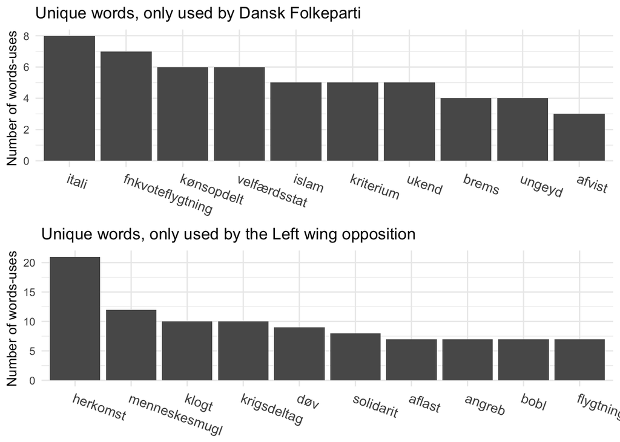

```r
#Function I have used in other work earlier - it makes it possible to generate multiple ggplots next to oneanother via the grid-fucntion. Found on stack.overflow
multiplot <- function(..., plotlist=NULL, file, cols=1, layout=NULL) {
  library(grid)

  # Make a list from the ... arguments and plotlist
  plots <- c(list(...), plotlist)

  numPlots = length(plots)

  # If layout is NULL, then use 'cols' to determine layout
  if (is.null(layout)) {
    # Make the panel
    # ncol: Number of columns of plots
    # nrow: Number of rows needed, calculated from # of cols
    layout <- matrix(seq(1, cols * ceiling(numPlots/cols)),
                    ncol = cols, nrow = ceiling(numPlots/cols))
  }

 if (numPlots==1) {
    print(plots[[1]])

  } else {
    # Set up the page
    grid.newpage()
    pushViewport(viewport(layout = grid.layout(nrow(layout), ncol(layout))))

    # Make each plot, in the correct location
    for (i in 1:numPlots) {
      # Get the i,j matrix positions of the regions that contain this subplot
      matchidx <- as.data.frame(which(layout == i, arr.ind = TRUE))

      print(plots[[i]], vp = viewport(layout.pos.row = matchidx$row,
                                      layout.pos.col = matchidx$col))
    }
  }
}

multiplot(df_barplot, leftwing_barplot)
```

## STEP 2.2 Differences in averages by using proportions

To complement the analysis above, I investigate the average us of words across the parties - it takes three steps:

1. Normalize the dtm from counts to proportions
2. Take the difference between one blocs’s proportion of a word and another bloc’s proportion of the same word.
3. Find the words with the highest absolute difference.

```r
# normalize into proportions
rowTotals <- rowSums(df_all_blocks) #create column with row totals, total number of words per document
head(rowTotals)
```

```
##      dtm.gov       dtm.df        dtm.s dtm.leftwing
##        19348         7981         8244        15490
```

```r
df_all_blocks <- df_all_blocks/rowTotals #change frequencies to proportions
df_all_blocks[,1:5] # how we have proportions.
```

```
##                   aalborg       aarhus  aarhusområd      abdalla
## dtm.gov      0.0000000000 5.168493e-05 0.0000000000 5.168493e-05
## dtm.df       0.0000000000 1.252976e-04 0.0001252976 0.000000e+00
## dtm.s        0.0001213003 8.491024e-04 0.0000000000 0.000000e+00
## dtm.leftwing 0.0000000000 6.455778e-05 0.0000000000 0.000000e+00
##                      åben
## dtm.gov      5.168493e-05
## dtm.df       3.758927e-04
## dtm.s        1.213003e-04
## dtm.leftwing 0.000000e+00
```

```r
# get difference in proportions
means.gov <- df_all_blocks[1,]
means.df <- df_all_blocks[2,]
means.s <- df_all_blocks[3,]
means.leftwing <- df_all_blocks[4,]

#Calculate the difference
score_gov_leftwing <- unlist(means.gov - means.leftwing) ##Government compared to leftwing
score_df_leftwing <- unlist(means.df - means.leftwing)##DF compared to leftwing
score_gov_df <- unlist(means.gov - means.df) ##Government compared to DF
```

And now, I can compare across theoretically relevant dimensions

### 2.2.1 Government vs. Leftwing

I start by finding the words with the highest difference in proportions between the government and the leftwing parties

```r
# find words with highest difference
score_gov_leftwing <- sort(score_gov_leftwing, decreasing=T) #Government compared to the leftwing
head(score_gov_leftwing,10) # Top words for government
```

```
##      kommun   udlænding       aftal       antal        regl    selvfølg
## 0.004549048 0.003916730 0.002171348 0.002158475 0.002081238 0.001849720
##        gang        stat        styr    hjemland
## 0.001758642 0.001758062 0.001757481 0.001653918
```

```r
tail(score_gov_leftwing,10) # Top words for leftwin
```

```
##            sam      flygtning        friskol          handl            syn
##   -0.002089272   -0.002153443   -0.002155572   -0.002168058   -0.002512722
##        problem           børn          fordi kvoteflygtning        mennesk
##   -0.002671066   -0.002942751   -0.003445373   -0.003807554   -0.003832913
```

And then, I can make a plot

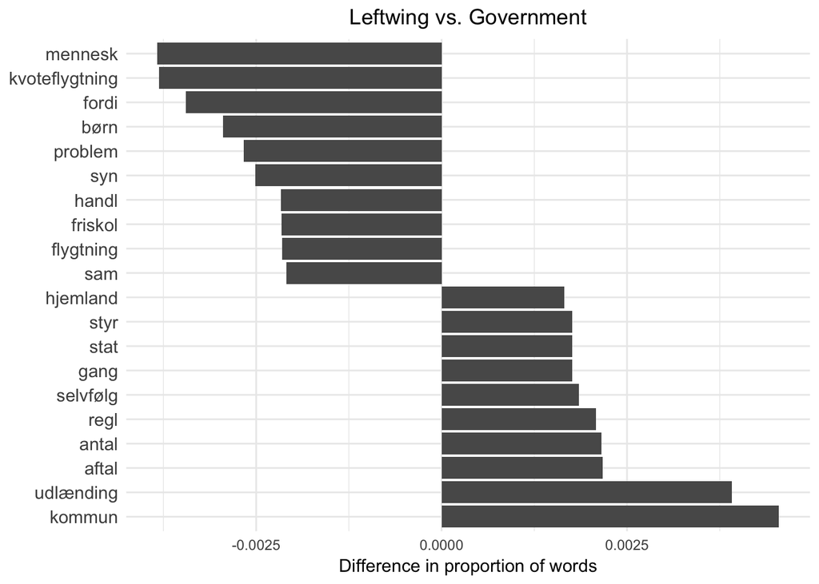

```r
#Make a dataframe for plotting
leftwing_gov_plot<-as.data.frame(score_gov_leftwing[c(1:10,5430:5439)])
#Make a variable of the names
leftwing_gov_plot$names<-names(score_gov_leftwing[c(1:10,5430:5439)])
#Rename
names(leftwing_gov_plot)[names(leftwing_gov_plot) == "score_gov_leftwing[c(1:10, 5430:5439)]"] <- "value"

#Order the names after the times a word is used
leftwing_gov_plot$names <- factor(leftwing_gov_plot$names, levels = leftwing_gov_plot$names[order(-leftwing_gov_plot$value)])

#Make the plot
plot1<-ggplot(leftwing_gov_plot, aes(x=names, y=value))+
  geom_histogram(stat="identity")+
  theme_minimal()+
  coord_flip()+
  theme(axis.text.y = element_text(size= 11),
        axis.title.y = element_blank())+
  ylab("Difference in proportion of words")+
  labs(title="Leftwing vs. Government")+
  theme(plot.title = element_text(hjust = 0.5))
plot1
```

```r
setwd("/Users/thorkilklint/Documents/Berkeley/PS239T_Computational/thorkil-klint-ps239T-final-project/Results")
ggsave(filename="word_proportion_leftwing_government.jpg",
       plot=plot1,
       width=18, height=12, units="cm")

#For presentation
#ggplot(leftwing_gov_plot, aes(x=names, y=value))+
  #geom_histogram(stat="identity")+
  #theme_minimal()+
  #coord_flip()+
  #theme(axis.text.y = element_text(size= 15),
        #axis.title.y = element_blank(),
        #title=element_text(size=18),
        #axis.title.x=element_text(size=15))+
  #ylab("Difference in proportion of words")+
  #labs(title="Leftwing vs. Government")+
  #theme(plot.title = element_text(hjust = 0.5))
```

### 2.2.2 Dansk Folkeparti vs. Leftwing

Now, I can find the words with the highest difference in proportions between the Danish People’s party and the leftwing parties

```r
# find words with highest difference
score_df_leftwing <- sort(score_df_leftwing, decreasing=T) #Government compared to the leftwing
head(score_df_leftwing,10) # Top words for government
```

```
##                bar                sid               loft
##        0.006442585        0.004703691        0.004571453
##          folketing              aftal                set
##        0.003766216        0.003610722        0.002983886
## beslutningsforslag               godt    parallelsamfund
##        0.002722185        0.002516362        0.002505952
##            hvorfor
##        0.002505604
```

```r
tail(score_df_leftwing,10) # Top words for leftwin
```

```
##  menneskeret   lovgivning        fordi    europæisk    flygtning
## -0.002198782 -0.002221690 -0.002499359 -0.002673595 -0.002742318
##          del          ret          sam         land      mennesk
## -0.002893994 -0.002893994 -0.003038381 -0.003057471 -0.004883831
```

Make a plot

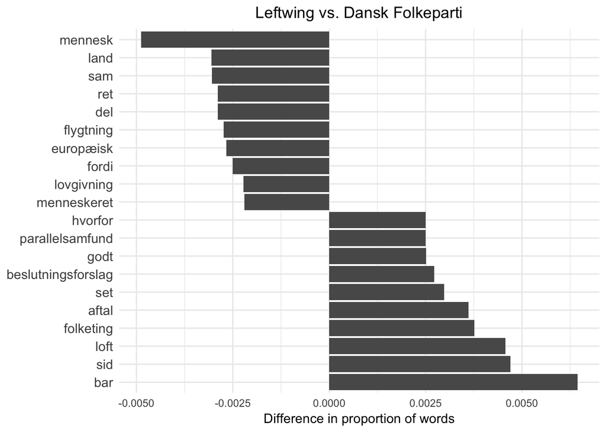

```r
#Make a dataframe for plotting
leftwing_df_plot<-as.data.frame(score_df_leftwing[c(1:10,5430:5439)])
#Make a variable of the names
leftwing_df_plot$names<-names(score_df_leftwing[c(1:10,5430:5439)])
#Rename
names(leftwing_df_plot)[names(leftwing_df_plot) == "score_df_leftwing[c(1:10, 5430:5439)]"] <- "value"

#Order the names after the times a word is used
leftwing_df_plot$names <- factor(leftwing_df_plot$names, levels = leftwing_df_plot$names[order(-leftwing_df_plot$value)])

#Make the plot
plot2<-ggplot(leftwing_df_plot, aes(x=names, y=value))+
  geom_histogram(stat="identity")+
  theme_minimal()+
  coord_flip()+
  theme(axis.text.y = element_text(size= 11),
        axis.title.y = element_blank())+
  ylab("Difference in proportion of words")+
  labs(title="Leftwing vs. Dansk Folkeparti")+
  theme(plot.title = element_text(hjust = 0.5))
plot2
```

```r
setwd("/Users/thorkilklint/Documents/Berkeley/PS239T_Computational/thorkil-klint-ps239T-final-project/Results")
ggsave(filename="word_proportion_leftwing_dansk_folkeparti.jpg",
       plot=plot2,
       width=18, height=12, units="cm")

#Make the plot for presentation
#ggplot(leftwing_df_plot, aes(x=names, y=value))+
  #geom_histogram(stat="identity")+
  #theme_minimal()+
  #coord_flip()+
  #theme(axis.text.y = element_text(size= 15),
        #axis.title.y = element_blank(),
        #title=element_text(size=18),
        #axis.title.x=element_text(size=15))+
  #ylab("Difference in proportion of words")+
  #labs(title="Leftwing vs. Dansk Folkeparti")+
  #theme(plot.title = element_text(hjust = 0.5))
```

Now, finally, I can look at words with the highest difference in proportions between the Government and the Danish People’s party

```r
# find words with highest difference
score_gov_df <- sort(score_gov_df, decreasing=T) #Government compared to the leftwing
head(score_gov_df,10) # Top words for government
```

```
##        kommun       danmark          stat          rigt international
##   0.003451913   0.002588877   0.002540391   0.002435435   0.002379067
##          sikr         først          regl         netop          borg
##   0.002090886   0.002061128   0.002054860   0.002025102   0.001964027
```

```r
tail(score_gov_df,10) # Top words for leftwin
```

```
##        opfat          and         lidt          syn         godt
## -0.002357166 -0.002429218 -0.003011850 -0.003054171 -0.003713537
##    folketing         loft      hvorfor          sid          bar
## -0.003984473 -0.004119161 -0.004170846 -0.005824790 -0.006426229
```

## STEP 2.3 Standardized Mean Difference

The above investigation does not take the the variability in word use into a count. E.g. it might be, that the differences above are driven by specific party members talking different than the party in general.I try to take this into account, by setting up a metric that takes the variability of word use into account

```r
# Subset into 2 dtms for each party
dtm.alt <- dtm.m.sort[dtm.m.sort$NumberItem<44,]
dtm.df <- dtm.m.sort[dtm.m.sort$NumberItem>45 & dtm.m.sort$NumberItem<184,]
dtm.el <- dtm.m.sort[dtm.m.sort$NumberItem>185 & dtm.m.sort$NumberItem<263,]
dtm.kf <- dtm.m.sort[dtm.m.sort$NumberItem>264 & dtm.m.sort$NumberItem<310,]
dtm.la <- dtm.m.sort[dtm.m.sort$NumberItem>311 & dtm.m.sort$NumberItem<388,]
dtm.rv <- dtm.m.sort[dtm.m.sort$NumberItem>389 & dtm.m.sort$NumberItem<416,]
dtm.s <- dtm.m.sort[dtm.m.sort$NumberItem>417 & dtm.m.sort$NumberItem<553,]
dtm.sf <- dtm.m.sort[dtm.m.sort$NumberItem>554 & dtm.m.sort$NumberItem<594,]
dtm.v <- dtm.m.sort[dtm.m.sort$NumberItem>595 & dtm.m.sort$NumberItem<773,]

# Make one for government and leftwing
dtm.leftwing<-rbind(dtm.el,dtm.rv,dtm.sf,dtm.alt)
dtm.gov<-rbind(dtm.v,dtm.la,dtm.kf)

#And remove the number item
dtm.leftwing<-dplyr::select(dtm.leftwing, -NumberItem)
dtm.gov<-dplyr::select(dtm.gov, -NumberItem)
dtm.df<-dplyr::select(dtm.df, -NumberItem)
```

Now, I can calculate means and variation on word use

```r
# calculate means and vars for all three blocs
means.df <- colMeans(dtm.df)
var.df <- colVars(as.matrix(dtm.df))

means.gov <- colMeans(dtm.gov)
var.gov <- colVars(as.matrix(dtm.gov))

means.leftwing<-colMeans(dtm.leftwing)
var.leftwing <- colVars(as.matrix(dtm.leftwing))
```

And then, I can compare as before, by getting and plotting the biggest differences between the blocs

### 2.3.1 Government vs. Leftwing

```r
#Government vs. Leftwing
num <- (means.gov - means.leftwing)
denom <- sqrt((var.gov/nrow(dtm.gov)) + (var.leftwing/nrow(dtm.leftwing)))
score <- num /denom

# sort and view
score <- sort(score, decreasing = TRUE)
head(score,10) # top Leftwing words
```

```
##           indgå            især          kommun     naturligvis
##        3.767647        3.595143        3.569546        3.230546
##            styr        værdisæt         begræns           såled
##        3.198314        3.094437        2.967962        2.966639
##            hjem parallelsamfund
##        2.956273        2.892854
```

```r
tail(score,10) # top Government words
```

```
##       udsat     mennesk        stop        tænk   fuldstænd       handl
##   -3.274255   -3.279543   -3.366318   -3.441998   -3.548985   -3.608925
##         vel høringssvar      forstå       fordi
##   -3.612315   -3.688447   -3.820275   -4.579237
```

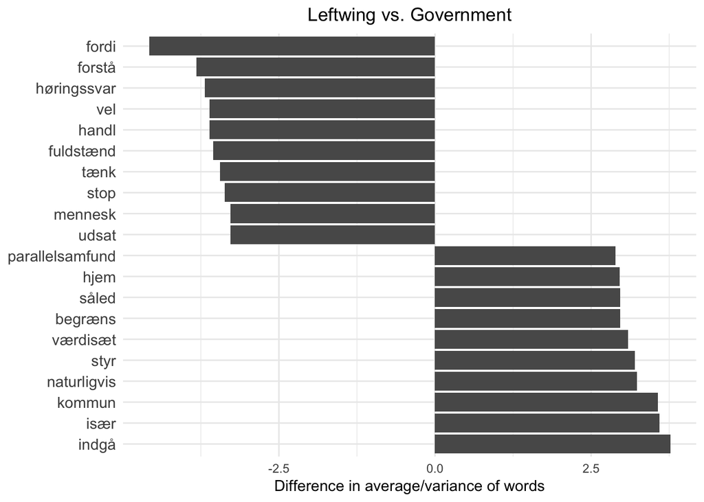

```r
#Make a dataframe for plotting
leftwing_gov_plot<-as.data.frame(score[c(1:10,4324:4333)])
#Make a variable of the names
leftwing_gov_plot$names<-names(score[c(1:10,4324:4333)])
#Rename
names(leftwing_gov_plot)[names(leftwing_gov_plot) == "score[c(1:10, 4324:4333)]"] <- "value"

#Order the names after the times a word is used
leftwing_gov_plot$names <- factor(leftwing_gov_plot$names, levels = leftwing_gov_plot$names[order(-leftwing_gov_plot$value)])

#Make the plot
ggplot(leftwing_gov_plot, aes(x=names, y=value))+
  geom_histogram(stat="identity")+
  theme_minimal()+
  coord_flip()+
  theme(axis.text.y = element_text(size= 11),
        axis.title.y = element_blank())+
  ylab("Difference in average/variance of words")+
  labs(title="Leftwing vs. Government")+
  theme(plot.title = element_text(hjust = 0.5))
```

### 2.3.2 Dansk Folkeparti vs. Leftwing

```r
#DF vs. Leftwing
num <- (means.df - means.leftwing)
denom <- sqrt((var.df/nrow(dtm.df)) + (var.leftwing/nrow(dtm.leftwing)))
score <- num /denom

# sort and view
score <- sort(score, decreasing = TRUE)
head(score,10) # top Leftwing words
```

```
##            loft        asylstop parallelsamfund             vid
##        3.275316        2.967259        2.787624        2.755150
##           lokal    tilstrømning            frav             bar
##        2.705663        2.616084        2.587240        2.554028
##          begynd           aftal
##        2.459390        2.424692
```

```r
tail(score,10) # top Government words
```

```
##         ell      famili         sær høringssvar         pas       fordi
##   -3.561742   -3.595797   -3.644070   -3.688447   -3.729206   -3.878481
##     mennesk         sam menneskeret   fuldstænd
##   -3.993358   -4.014834   -4.051653   -4.886266
```

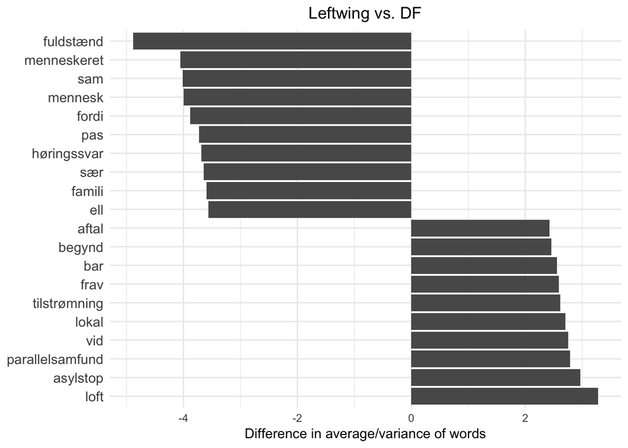

```r
#Make a dataframe for plotting
leftwing_df_plot<-as.data.frame(score[c(1:10,3443:3452)])
#Make a variable of the names
leftwing_df_plot$names<-names(score[c(1:10,3443:3452)])
#Rename
names(leftwing_df_plot)[names(leftwing_df_plot) == "score[c(1:10, 3443:3452)]"] <- "value"

#Order the names after the times a word is used
leftwing_df_plot$names <- factor(leftwing_df_plot$names, levels = leftwing_df_plot$names[order(-leftwing_df_plot$value)])

#Make the plot
ggplot(leftwing_df_plot, aes(x=names, y=value))+
  geom_histogram(stat="identity")+
  theme_minimal()+
  coord_flip()+
  theme(axis.text.y = element_text(size= 11),
        axis.title.y = element_blank())+
  ylab("Difference in average/variance of words")+
  labs(title="Leftwing vs. DF")+
  theme(plot.title = element_text(hjust = 0.5))
```